# Lab 2: Functions and Environments

## Lab 2: Functions and Environments

We are interested in the impact of different diets on chicken growth. We have a dataset giving the weights of chickens on each of four different diets over the first several weeks of life in the `ChickWeight` dataset.

We can first look at the data and get a summary:

```r
data(ChickWeight)
head(ChickWeight)
```

```
##   weight Time Chick Diet
## 1     42    0     1    1
## 2     51    2     1    1
## 3     59    4     1    1
## 4     64    6     1    1
## 5     76    8     1    1
## 6     93   10     1    1
```

```r
summary(ChickWeight)
```

```
##      weight           Time           Chick     Diet
##  Min.   : 35.0   Min.   : 0.00   13     : 12   1:220
##  1st Qu.: 63.0   1st Qu.: 4.00   9      : 12   2:120
##  Median :103.0   Median :10.00   20     : 12   3:120
##  Mean   :121.8   Mean   :10.72   10     : 12   4:118
##  3rd Qu.:163.8   3rd Qu.:16.00   17     : 12
##  Max.   :373.0   Max.   :21.00   19     : 12
##                                  (Other):506
```

Questions:

- What type of object is `ChickWeight`?
- What types of data are the columns of `ChickWeight`? What happens when you try querying with either `typeof` or `class`? Do you get different results? Why?

We can also make a plot to see what's going on a little better. Don't worry about `ggplot` for this class — it's a nice plotting package, and if you take Exploratory Data Analysis you'll use it more, but you won't have to know about it for our class.

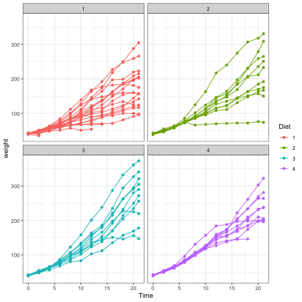

```r
library(ggplot2)
ggplot(ChickWeight, aes(x = Time, y = weight, color = Diet, group = Chick)) +
    geom_point() +
    geom_line() +
    facet_wrap(~ Diet)
```

Suppose we are interested in how much weight the chickens have put on after four days on diet 1. We write the following code:

```r
time_zero_indices <- ChickWeight$Time == 0 & ChickWeight$Diet == 1
end_time_indices <- ChickWeight$Time == 4 & ChickWeight$Diet == 1
end_weight <- mean(ChickWeight$weight[end_time_indices])
initial_weight <- mean(ChickWeight$weight[time_zero_indices])
end_weight - initial_weight
```

```
## [1] 15.07368
```

We then decide that we might want to be able to compute this value for any diet and any end time, and so we would like to write a function to do so. We try to do so in the following way:

```r
n_diets <- length(unique(ChickWeight$Diet))
weight_gained_vector <- rep(NA, n_diets)
set_weight_gained <- function(diet, end_time) {
    time_zero_indices <- ChickWeight$Time == 0 & ChickWeight$Diet == diet
    end_time_indices <- ChickWeight$Time == end_time & ChickWeight$Diet == diet
    end_weight <- mean(ChickWeight$weight[end_time_indices])
    initial_weight <- mean(ChickWeight$weight[time_zero_indices])
    weight_gained_vector[diet] <- end_weight - initial_weight
}
for(diet in 1:4) {
    set_weight_gained(diet = diet, end_time = 4)
}
```

Questions:

- What happens when you run the code above? Does the `weight_gained_vector` change after calling the `set_weight_gained` function? Why or why not?
- Map out the environments that are used when we call the `set_weight_gained` vector, and describe which environment each variable is in.
- Explain what the `diet = diet` part of the code in the for loop means. What is the formal argument and what is the actual argument?

The `ls()` function lists all of the variables present in the environment `ls` is called from. We can use it to see what variables are present inside the function call by printing out the result from `ls` in the middle of the function. Try that in the `set_weight_gained` function:

```r
set_weight_gained <- function(diet, end_time) {
    time_zero_indices <- ChickWeight$Time == 0 & ChickWeight$Diet == diet
    end_time_indices <- ChickWeight$Time == end_time & ChickWeight$Diet == diet
    end_weight <- mean(ChickWeight$weight[end_time_indices])
    initial_weight <- mean(ChickWeight$weight[time_zero_indices])
    print(ls())
    weight_gained_vector[diet] <- end_weight - initial_weight
}
set_weight_gained(diet = diet, end_time = 4)
```

```
## [1] "diet"              "end_time"          "end_time_indices"
## [4] "end_weight"        "initial_weight"    "time_zero_indices"
```

We will see better tools for investigating the variables available in function environments when we talk about debugging, but for now this gives us a peek at what is happening when the function is called.

Your final task: Make a function that computes the average amount of weight gained by chickens on one of the diets after a given period of time. That is, make a function that takes `diet` and `end_time`, like `set_weight_gained` did, but that returns the weight gained instead of trying to assign the output to a variable in the global environment.